# Debt_김재열

## 미국 금리변화에 따른 (가계 & 기업) 부채 변화

- 자료출처 : 한국은행

```python
import pandas as pd
import matplotlib.pyplot as plt
import platform
data=pd.read_csv('가계신용동향(분기별).csv', encoding='euc_kr')
data.head()
```

|  | Unnamed: 0 | Unnamed: 1 | 20151/4 | 20152/4 | 20153/4 | 20154/4 | 20161/4 | 20162/4 | 20163/4 | 20164/4 | ... | 20194/4 | 20201/4 | 20202/4 | 20203/4 | 20204/4 | 20211/4 | 20212/4 | 20213/4 | 20214/4 | 20221/4 |
| --- | --- | --- | --- | --- | --- | --- | --- | --- | --- | --- | --- | --- | --- | --- | --- | --- | --- | --- | --- | --- | --- |
| 0 | 가계신용 | 금액 | 1098.3 | 1131.5 | 1164.9 | 1203.1 | 1223.7 | 1257.5 | 1296.5 | 1342.5 | ... | 1600.3 | 1611.4 | 1637.3 | 1681.8 | 1727.4 | 1764.6 | 1808.2 | 1843.0 | 1862.1 | 1859.4 |
| 1 | NaN | 전년동기증감액 | 75.9 | 95.6 | 108.5 | 117.8 | 125.4 | 126.1 | 131.6 | 139.4 | ... | 63.6 | 71.5 | 80.5 | 109.3 | 127.1 | 153.2 | 170.9 | 161.2 | 134.1 | 94.8 |
| 2 | NaN | 전년동기증감율(%) | 7.4 | 9.2 | 10.3 | 10.9 | 11.4 | 11.1 | 11.3 | 11.6 | ... | 4.1 | 4.6 | 5.2 | 7.0 | 7.9 | 9.5 | 10.4 | 9.6 | 7.8 | 5.4 |
| 3 | 가계대출 | 금액 | 1039.3 | 1072.0 | 1101.4 | 1138.0 | 1158.4 | 1191.6 | 1228.6 | 1269.8 | ... | 1504.6 | 1521.8 | 1546.0 | 1585.7 | 1631.5 | 1666.7 | 1707.7 | 1742.4 | 1755.8 | 1752.7 |
| 4 | NaN | 전년동기증감액 | 74.0 | 93.6 | 102.4 | 112.9 | 119.1 | 119.6 | 127.1 | 131.9 | ... | 57.9 | 70.1 | 78.0 | 104.3 | 126.9 | 144.5 | 161.7 | 156.7 | 123.8 | 86.0 |

5 rows × 31 columns

```python
debt_columns=[]
for i in range(len(data.columns)):
    if i == 0 or i==1:
        debt_columns.append(data.columns[i])
    else:
        debt_columns.append(data.columns[i][:4]+'/' +data.columns[i][4:])
```

```python
data.columns=debt_columns
data
```

|  | Unnamed: 0 | Unnamed: 1 | 2015/1/4 | 2015/2/4 | 2015/3/4 | 2015/4/4 | 2016/1/4 | 2016/2/4 | 2016/3/4 | 2016/4/4 | ... | 2019/4/4 | 2020/1/4 | 2020/2/4 | 2020/3/4 | 2020/4/4 | 2021/1/4 | 2021/2/4 | 2021/3/4 | 2021/4/4 | 2022/1/4 |
| --- | --- | --- | --- | --- | --- | --- | --- | --- | --- | --- | --- | --- | --- | --- | --- | --- | --- | --- | --- | --- | --- |
| 0 | 가계신용 | 금액 | 1098.3 | 1131.5 | 1164.9 | 1203.1 | 1223.7 | 1257.5 | 1296.5 | 1342.5 | ... | 1600.3 | 1611.4 | 1637.3 | 1681.8 | 1727.4 | 1764.6 | 1808.2 | 1843.0 | 1862.1 | 1859.4 |
| 1 | NaN | 전년동기증감액 | 75.9 | 95.6 | 108.5 | 117.8 | 125.4 | 126.1 | 131.6 | 139.4 | ... | 63.6 | 71.5 | 80.5 | 109.3 | 127.1 | 153.2 | 170.9 | 161.2 | 134.1 | 94.8 |
| 2 | NaN | 전년동기증감율(%) | 7.4 | 9.2 | 10.3 | 10.9 | 11.4 | 11.1 | 11.3 | 11.6 | ... | 4.1 | 4.6 | 5.2 | 7.0 | 7.9 | 9.5 | 10.4 | 9.6 | 7.8 | 5.4 |
| 3 | 가계대출 | 금액 | 1039.3 | 1072.0 | 1101.4 | 1138.0 | 1158.4 | 1191.6 | 1228.6 | 1269.8 | ... | 1504.6 | 1521.8 | 1546.0 | 1585.7 | 1631.5 | 1666.7 | 1707.7 | 1742.4 | 1755.8 | 1752.7 |
| 4 | NaN | 전년동기증감액 | 74.0 | 93.6 | 102.4 | 112.9 | 119.1 | 119.6 | 127.1 | 131.9 | ... | 57.9 | 70.1 | 78.0 | 104.3 | 126.9 | 144.5 | 161.7 | 156.7 | 123.8 | 86.0 |
| 5 | NaN | 전년동기증감율(%) | 7.7 | 9.6 | 10.3 | 11.0 | 11.5 | 11.2 | 11.5 | 11.6 | ... | 4.0 | 4.8 | 5.3 | 7.0 | 8.4 | 9.5 | 10.5 | 9.9 | 7.6 | 5.2 |
| 6 | 판매신용 | 금액 | 59.0 | 59.5 | 63.4 | 65.1 | 65.2 | 65.9 | 67.9 | 72.7 | ... | 95.7 | 89.6 | 91.2 | 96.1 | 95.9 | 97.9 | 100.4 | 100.6 | 106.3 | 106.7 |
| 7 | NaN | 전년동기증감액 | 1.9 | 2.0 | 6.0 | 4.9 | 6.2 | 6.4 | 4.4 | 7.6 | ... | 5.6 | 1.4 | 2.5 | 5.0 | 0.2 | 8.7 | 9.2 | 4.5 | 10.4 | 8.7 |
| 8 | NaN | 전년동기증감율(%) | 3.3 | 3.5 | 10.5 | 8.1 | 10.5 | 10.8 | 7.0 | 11.6 | ... | 6.3 | 1.6 | 2.8 | 5.5 | 0.2 | 9.7 | 10.1 | 4.6 | 10.8 | 8.9 |

9 rows × 31 columns

```python
data.columns[2:]
```

```
Index(['2015/1/4', '2015/2/4', '2015/3/4', '2015/4/4', '2016/1/4', '2016/2/4',
       '2016/3/4', '2016/4/4', '2017/1/4', '2017/2/4', '2017/3/4', '2017/4/4',
       '2018/1/4', '2018/2/4', '2018/3/4', '2018/4/4', '2019/1/4', '2019/2/4',
       '2019/3/4', '2019/4/4', '2020/1/4', '2020/2/4', '2020/3/4', '2020/4/4',
       '2021/1/4', '2021/2/4', '2021/3/4', '2021/4/4', '2022/1/4'],
      dtype='object')
```

```python
home_credit=data.iloc[0][18:]
home_debt=data.iloc[3][18:]
sell_credit=data.iloc[6][18:]
print(home_credit,home_debt,sell_credit)
```

```
2019/1/4    1539.9
2019/2/4    1556.7
2019/3/4    1572.5
2019/4/4    1600.3
2020/1/4    1611.4
2020/2/4    1637.3
2020/3/4    1681.8
2020/4/4    1727.4
2021/1/4    1764.6
2021/2/4    1808.2
2021/3/4    1843.0
2021/4/4    1862.1
2022/1/4    1859.4
Name: 0, dtype: object 2019/1/4    1451.7
2019/2/4    1468.0
2019/3/4    1481.4
2019/4/4    1504.6
2020/1/4    1521.8
2020/2/4    1546.0
2020/3/4    1585.7
2020/4/4    1631.5
2021/1/4    1666.7
2021/2/4    1707.7
2021/3/4    1742.4
2021/4/4    1755.8
2022/1/4    1752.7
Name: 3, dtype: object 2019/1/4     88.2
2019/2/4     88.7
2019/3/4     91.1
2019/4/4     95.7
2020/1/4     89.6
2020/2/4     91.2
2020/3/4     96.1
2020/4/4     95.9
2021/1/4     97.9
2021/2/4    100.4
2021/3/4    100.6
2021/4/4    106.3
2022/1/4    106.7
Name: 6, dtype: object
```

```python
home_credit=home_credit.astype('int64')
home_debt=home_debt.astype('int64')
sell_credit=sell_credit.astype('int64')
print(home_credit ,home_debt,sell_credit)
```

```
2019/1/4    1539
2019/2/4    1556
2019/3/4    1572
2019/4/4    1600
2020/1/4    1611
2020/2/4    1637
2020/3/4    1681
2020/4/4    1727
2021/1/4    1764
2021/2/4    1808
2021/3/4    1843
2021/4/4    1862
2022/1/4    1859
Name: 0, dtype: int64 2019/1/4    1451
2019/2/4    1468
2019/3/4    1481
2019/4/4    1504
2020/1/4    1521
2020/2/4    1546
2020/3/4    1585
2020/4/4    1631
2021/1/4    1666
2021/2/4    1707
2021/3/4    1742
2021/4/4    1755
2022/1/4    1752
Name: 3, dtype: int64 2019/1/4     88
2019/2/4     88
2019/3/4     91
2019/4/4     95
2020/1/4     89
2020/2/4     91
2020/3/4     96
2020/4/4     95
2021/1/4     97
2021/2/4    100
2021/3/4    100
2021/4/4    106
2022/1/4    106
Name: 6, dtype: int64
```

```python
# home_credit=pd.to_datetime(home_credit.index)
# home_credit
```

## 미국금리 데이터 가져오기

```python
ame_ir=pd.read_csv('미국금리_분기.csv', encoding='euc_kr')
ame_ir
```

|  | 날짜 | 실제 | 이전 |
| --- | --- | --- | --- |
| 0 | 2019/1/4 | 2.50% | 2.50% |
| 1 | 2019/2/4 | 2.50% | 2.50% |
| 2 | 2019/3/4 | 2.25% | 2.50% |
| 3 | 2019/4/4 | 1.75% | 2.00% |
| 4 | 2020/1/4 | 1.75% | 1.75% |
| 5 | 2020/2/4 | 0.25% | 0.25% |
| 6 | 2020/3/4 | 0.25% | 0.25% |
| 7 | 2020/4/4 | 0.25% | 0.25% |
| 8 | 2021/1/4 | 0.25% | 0.25% |
| 9 | 2021/2/4 | 0.25% | 0.25% |
| 10 | 2021/3/4 | 0.25% | 0.25% |
| 11 | 2021/4/4 | 0.25% | 0.25% |
| 12 | 2022/1/4 | 0.25% | 0.25% |

```python
# % 빼기, 실수로 만들기, 데이터타입 변경
ame_ir['실제']=ame_ir['실제'].apply(lambda x: x.replace('%', ''))
```

```python
# '실제' 컬럼 float로 형변환
ame_ir['실제']=ame_ir['실제'].astype('float')
```

```python
ame_ir.info()
```

```
<class 'pandas.core.frame.DataFrame'>
RangeIndex: 13 entries, 0 to 12
Data columns (total 3 columns):
 #   Column  Non-Null Count  Dtype
---  ------  --------------  -----
 0   날짜      13 non-null     object
 1   실제      13 non-null     float64
 2   이전      13 non-null     object
dtypes: float64(1), object(2)
memory usage: 440.0+ bytes
```

```python
#'날짜' 컬럼 데이터타입 변경
# ame_ir['날짜']=pd.to_datetime(ame_ir['날짜'])
# ame_ir['날짜']
```

```python
ame_ir.info()
```

```
<class 'pandas.core.frame.DataFrame'>
RangeIndex: 13 entries, 0 to 12
Data columns (total 3 columns):
 #   Column  Non-Null Count  Dtype
---  ------  --------------  -----
 0   날짜      13 non-null     object
 1   실제      13 non-null     float64
 2   이전      13 non-null     object
dtypes: float64(1), object(2)
memory usage: 440.0+ bytes
```

```python
# 그래프 X축에 들어갈 값을 DateTime으로 변경
# home_credit2=pd.to_datetime(home_credit.index)
# home_credit2
```

```python
# 그래프 X축에 들어갈 값을 DateTime으로 변경
# home_debt2=pd.to_datetime(home_debt.index)
# home_debt2
```

[output not shown]

```python
ame_ir['실제'].values
```

[output not shown]

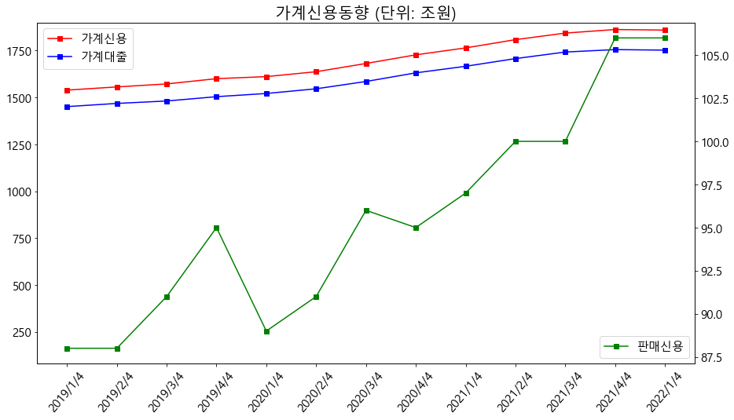

```python
if platform.system() == 'Windows':
    plt.rc('font', family='Malgun Gothic')
else:
    plt.rc('font', family='AppleGothic')


plt.figure(figsize=(15,8))
plt.title('가계신용동향 (단위: 조원)', fontsize=20)
plt.ylim(80,1900)

plt.plot(home_credit.index,home_credit.values, 'r-',marker='s',label='가계신용')
plt.plot(home_debt.index,home_debt.values, 'b-',marker='s',label='가계대출')
plt.legend(fontsize=15)
plt.yticks(fontsize=15)
plt.xticks(rotation=50, fontsize=15)
plt.twinx()

plt.plot(sell_credit.index,sell_credit.values, 'g-',marker='s',label='판매신용')
plt.legend(loc='lower right',fontsize=15)

plt.yticks(fontsize=15)
plt.show()
```

## '가계신용동향' 차트 분석

- 가계신용 = 가계대출 + 판매신용
- 판매신용이란? : 재화의 판매자 ,생산자가 서비스제공자에게 제공하는 외상(신용)거래를 포괄
- 가계대출은 코로나가 발생이전인 2019년부터 지속적인 증가 추세
- 판매신용은 가계대출 대비 등락폭이 큼
- 판매신용은 소비성향으로 볼 수 있음

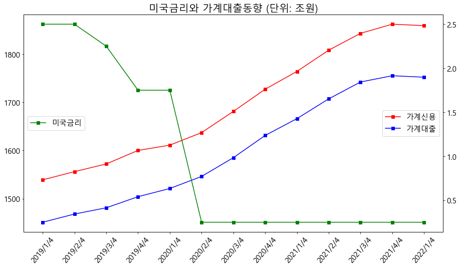

```python
plt.figure(figsize=(15,8))
plt.title('미국금리와 가계대출동향 (단위: 조원)', fontsize=20)

plt.plot(home_credit.index,home_credit.values, 'r-',marker='s',label='가계신용')
plt.plot(home_debt.index,home_debt.values, 'b-',marker='s',label='가계대출')
plt.legend(fontsize=15, loc=5)
plt.yticks(fontsize=15)
plt.xticks(rotation=50, fontsize=15)

plt.twinx()
plt.plot(ame_ir['날짜'].values, ame_ir['실제'].values, 'g-',marker='s', label='미국금리')
plt.yticks(fontsize=15)
plt.legend(fontsize=15, loc=6)
```

## '미국금리와 가계대출동향' 차트 분석

- 코로나 이후 미국은 경제를 활성화 시키기 위해 금리를 대폭 낮춤(0에 가까운 0.25%)
- 낮아진 금리에 따라 가계대출은 지속적으로 증가하는 추세 fea.영끌족
- 2022년 들어 코로나 기간 동안 과열된 경제를 잡기위해 금리를 지속적으로 올리고 있음
- 금리 상승에 따라 이자가 상승함에 따라 단기적으로는 가계대출 금액이 상승할 수 있으나
- 장기적으로는 가계대출이 감소할 것으로 예상

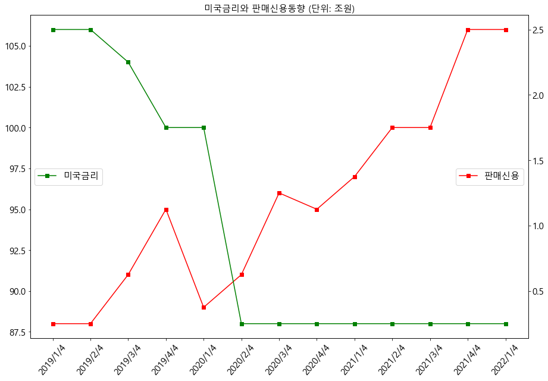

```python
plt.title('미국금리와 판매신용동향 (단위: 조원)', fontsize=15)
#plt.plot(home_credit.index,home_credit.values, 'r-',marker='s',label='가계신용')
plt.plot(sell_credit.index,sell_credit.values, 'r-',marker='s',label='판매신용')
plt.legend(fontsize=15, loc=5)
plt.yticks(fontsize=15)
plt.xticks(rotation=50, fontsize=15)

plt.twinx()
plt.plot(ame_ir['날짜'].values, ame_ir['실제'].values, 'g-',marker='s', label='미국금리')
plt.yticks(fontsize=15)
plt.legend(fontsize=15, loc=6)
```

[output not shown]

## 기업자금조달 데이터 전처리

1. 기업 자금조달 유형
   - 은행대출
   - 직접금융(주식발행, 회사채)

*출처 : 한국은행

```python
com_data=pd.read_csv('기업자금조달.csv',encoding='euc_kr')
com_data
```

|  | Unnamed: 0 | 201901월 | 201902월 | 201903월 | 201904월 | 201905월 | 201906월 | 201907월 | 201908월 | 201909월 | ... | 202108월 | 202109월 | 202110월 | 202111월 | 202112월 | 202201월 | 202202월 | 202203월 | 202204월 | 202205월 |
| --- | --- | --- | --- | --- | --- | --- | --- | --- | --- | --- | --- | --- | --- | --- | --- | --- | --- | --- | --- | --- | --- |
| 0 | 직접금융 | 13.6 | 11.9 | 14.6 | 19.7 | 13.9 | 14.5 | 17.1 | 14.5 | 13.2 | ... | 19.4 | 19.6 | 19.2 | 19.5 | 10.1 | 27.5 | 15.5 | 13.8 | 20.1 | 19.4 |
| 1 | 대기업 | 5.9 | 4.0 | 3.7 | 5.0 | 3.5 | 4.8 | 6.2 | 1.7 | 2.7 | ... | 4.6 | 6.4 | 5.1 | 3.7 | 1.4 | 15.9 | 6.5 | 2.3 | 8.4 | 2.4 |
| 2 | 중소기업 | 0.2 | 0.3 | 0.2 | 0.0 | 0.1 | 0.3 | 0.5 | 0.4 | 0.2 | ... | 0.5 | 0.6 | 0.6 | 0.2 | 0.4 | 0.4 | 0.3 | 0.4 | 0.1 | 0.5 |
| 3 | 금융채 | 7.1 | 7.0 | 9.3 | 13.3 | 8.5 | 7.9 | 9.8 | 11.4 | 9.0 | ... | 12.4 | 11.6 | 12.1 | 13.1 | 7.1 | 10.9 | 8.3 | 9.3 | 10.1 | 15.6 |
| 4 | ABS | 0.4 | 0.6 | 1.5 | 1.5 | 1.9 | 1.4 | 0.6 | 1.0 | 1.3 | ... | 1.9 | 1.0 | 1.4 | 2.4 | 1.3 | 0.4 | 0.5 | 1.7 | 1.5 | 1.0 |
| 5 | 기업대출 | 831.7 | 836.1 | 837.2 | 843.8 | 849.9 | 851.9 | 853.3 | 856.8 | 861.8 | ... | 1041.3 | 1049.0 | 1059.3 | 1068.4 | 1065.7 | 1079.0 | 1085.3 | 1093.9 | 1106.0 | 1119.2 |

6 rows × 42 columns

```python
com_data=com_data.set_index('Unnamed: 0')
com_data
```

| Unnamed: 0 | 201901월 | 201902월 | 201903월 | 201904월 | 201905월 | 201906월 | 201907월 | 201908월 | 201909월 | 201910월 | ... | 202108월 | 202109월 | 202110월 | 202111월 | 202112월 | 202201월 | 202202월 | 202203월 | 202204월 | 202205월 |
| --- | --- | --- | --- | --- | --- | --- | --- | --- | --- | --- | --- | --- | --- | --- | --- | --- | --- | --- | --- | --- | --- |
| 직접금융 | 13.6 | 11.9 | 14.6 | 19.7 | 13.9 | 14.5 | 17.1 | 14.5 | 13.2 | 20.7 | ... | 19.4 | 19.6 | 19.2 | 19.5 | 10.1 | 27.5 | 15.5 | 13.8 | 20.1 | 19.4 |
| 대기업 | 5.9 | 4.0 | 3.7 | 5.0 | 3.5 | 4.8 | 6.2 | 1.7 | 2.7 | 7.4 | ... | 4.6 | 6.4 | 5.1 | 3.7 | 1.4 | 15.9 | 6.5 | 2.3 | 8.4 | 2.4 |
| 중소기업 | 0.2 | 0.3 | 0.2 | 0.0 | 0.1 | 0.3 | 0.5 | 0.4 | 0.2 | 0.2 | ... | 0.5 | 0.6 | 0.6 | 0.2 | 0.4 | 0.4 | 0.3 | 0.4 | 0.1 | 0.5 |
| 금융채 | 7.1 | 7.0 | 9.3 | 13.3 | 8.5 | 7.9 | 9.8 | 11.4 | 9.0 | 10.9 | ... | 12.4 | 11.6 | 12.1 | 13.1 | 7.1 | 10.9 | 8.3 | 9.3 | 10.1 | 15.6 |
| ABS | 0.4 | 0.6 | 1.5 | 1.5 | 1.9 | 1.4 | 0.6 | 1.0 | 1.3 | 2.3 | ... | 1.9 | 1.0 | 1.4 | 2.4 | 1.3 | 0.4 | 0.5 | 1.7 | 1.5 | 1.0 |
| 기업대출 | 831.7 | 836.1 | 837.2 | 843.8 | 849.9 | 851.9 | 853.3 | 856.8 | 861.8 | 869.2 | ... | 1041.3 | 1049.0 | 1059.3 | 1068.4 | 1065.7 | 1079.0 | 1085.3 | 1093.9 | 1106.0 | 1119.2 |

6 rows × 41 columns

```python
com_data.columns[0][:-1]
```

```
'201901'
```

```python
col_name=[]
for i in range(len(com_data.columns)):
    col_name.append(com_data.columns[i][:4]+'-'+com_data.columns[i][4:-1])
```

```python
com_data.columns=col_name
com_data
```

| Unnamed: 0 | 2019-01 | 2019-02 | 2019-03 | 2019-04 | 2019-05 | 2019-06 | 2019-07 | 2019-08 | 2019-09 | 2019-10 | ... | 2021-08 | 2021-09 | 2021-10 | 2021-11 | 2021-12 | 2022-01 | 2022-02 | 2022-03 | 2022-04 | 2022-05 |
| --- | --- | --- | --- | --- | --- | --- | --- | --- | --- | --- | --- | --- | --- | --- | --- | --- | --- | --- | --- | --- | --- |
| 직접금융 | 13.6 | 11.9 | 14.6 | 19.7 | 13.9 | 14.5 | 17.1 | 14.5 | 13.2 | 20.7 | ... | 19.4 | 19.6 | 19.2 | 19.5 | 10.1 | 27.5 | 15.5 | 13.8 | 20.1 | 19.4 |
| 대기업 | 5.9 | 4.0 | 3.7 | 5.0 | 3.5 | 4.8 | 6.2 | 1.7 | 2.7 | 7.4 | ... | 4.6 | 6.4 | 5.1 | 3.7 | 1.4 | 15.9 | 6.5 | 2.3 | 8.4 | 2.4 |
| 중소기업 | 0.2 | 0.3 | 0.2 | 0.0 | 0.1 | 0.3 | 0.5 | 0.4 | 0.2 | 0.2 | ... | 0.5 | 0.6 | 0.6 | 0.2 | 0.4 | 0.4 | 0.3 | 0.4 | 0.1 | 0.5 |
| 금융채 | 7.1 | 7.0 | 9.3 | 13.3 | 8.5 | 7.9 | 9.8 | 11.4 | 9.0 | 10.9 | ... | 12.4 | 11.6 | 12.1 | 13.1 | 7.1 | 10.9 | 8.3 | 9.3 | 10.1 | 15.6 |
| ABS | 0.4 | 0.6 | 1.5 | 1.5 | 1.9 | 1.4 | 0.6 | 1.0 | 1.3 | 2.3 | ... | 1.9 | 1.0 | 1.4 | 2.4 | 1.3 | 0.4 | 0.5 | 1.7 | 1.5 | 1.0 |
| 기업대출 | 831.7 | 836.1 | 837.2 | 843.8 | 849.9 | 851.9 | 853.3 | 856.8 | 861.8 | 869.2 | ... | 1041.3 | 1049.0 | 1059.3 | 1068.4 | 1065.7 | 1079.0 | 1085.3 | 1093.9 | 1106.0 | 1119.2 |

6 rows × 41 columns

```python
dir_fin=com_data.loc['직접금융'][:]
bank_loan=com_data.loc['기업대출'][:]
print(dir_fin, bank_loan)
```

```
2019-01    13.6
2019-02    11.9
2019-03    14.6
2019-04    19.7
2019-05    13.9
2019-06    14.5
2019-07    17.1
2019-08    14.5
2019-09    13.2
2019-10    20.7
2019-11    12.2
2019-12     9.5
2020-01    11.2
2020-02    17.1
2020-03    16.1
2020-04    11.5
2020-05    16.1
2020-06    19.5
2020-07    19.8
2020-08    15.1
2020-09    17.3
2020-10    20.7
2020-11    16.3
2020-12    13.8
2021-01    15.5
2021-02    20.0
2021-03    24.4
2021-04    24.9
2021-05    16.3
2021-06    21.7
2021-07    21.0
2021-08    19.4
2021-09    19.6
2021-10    19.2
2021-11    19.5
2021-12    10.1
2022-01    27.5
2022-02    15.5
2022-03    13.8
2022-04    20.1
```

[output cut: 28 more lines]

```
2021-04    1011.4
2021-05    1017.1
2021-06    1022.1
2021-07    1033.5
2021-08    1041.3
2021-09    1049.0
2021-10    1059.3
2021-11    1068.4
2021-12    1065.7
2022-01    1079.0
2022-02    1085.3
2022-03    1093.9
2022-04    1106.0
2022-05    1119.2
Name: 기업대출, dtype: float64
```

```python
dir_fin=dir_fin.astype('float')
dir_fin.astype('int64')
```

```
2019-01    13
2019-02    11
2019-03    14
2019-04    19
2019-05    13
2019-06    14
2019-07    17
2019-08    14
2019-09    13
2019-10    20
2019-11    12
2019-12     9
2020-01    11
2020-02    17
2020-03    16
2020-04    11
2020-05    16
2020-06    19
2020-07    19
2020-08    15
2020-09    17
2020-10    20
2020-11    16
2020-12    13
2021-01    15
2021-02    20
2021-03    24
2021-04    24
2021-05    16
2021-06    21
2021-07    21
2021-08    19
2021-09    19
2021-10    19
2021-11    19
2021-12    10
2022-01    27
2022-02    15
2022-03    13
2022-04    20
2022-05    19
Name: 직접금융, dtype: int64
```

```python
bank_loan=bank_loan.astype('float')
bank_loan.astype('int64')
```

```
2019-01     831
2019-02     836
2019-03     837
2019-04     843
2019-05     849
2019-06     851
2019-07     853
2019-08     856
2019-09     861
2019-10     869
2019-11     875
2019-12     869
2020-01     877
2020-02     882
2020-03     901
2020-04     929
2020-05     945
2020-06     946
2020-07     955
2020-08     961
2020-09     966
2020-10     975
2020-11     982
2020-12     976
2021-01     986
2021-02     995
2021-03    1000
2021-04    1011
2021-05    1017
2021-06    1022
2021-07    1033
2021-08    1041
2021-09    1049
2021-10    1059
2021-11    1068
2021-12    1065
2022-01    1079
2022-02    1085
2022-03    1093
2022-04    1106
2022-05    1119
Name: 기업대출, dtype: int64
```

```python
# 기업자금조달 , 미국금리 컬럼 양식 맞추기
```

## 월별 미국금리 데이터 가져오기

```python
ame_ir_m=pd.read_csv('미국금리_월.csv', encoding='euc_kr')
ame_ir_m
```

|  | 날짜 | 실제 | 이전 |
| --- | --- | --- | --- |
| 0 | 2019-01 | 2.50% | 2.25% |
| 1 | 2019-02 | 2.50% | 2.50% |
| 2 | 2019-03 | 2.50% | 2.50% |
| 3 | 2019-04 | 2.50% | 2.50% |
| 4 | 2019-05 | 2.50% | 2.50% |
| 5 | 2019-06 | 2.50% | 2.50% |
| 6 | 2019-07 | 2.50% | 2.50% |
| 7 | 2019-08 | 2.25% | 2.50% |
| 8 | 2019-09 | 2.25% | 2.50% |
| 9 | 2019-10 | 2.00% | 2.25% |
| 10 | 2019-11 | 1.75% | 2.00% |
| 11 | 2019-12 | 1.75% | 2.00% |
| 12 | 2020-01 | 1.75% | 1.75% |
| 13 | 2020-02 | 1.75% | 1.75% |
| 14 | 2020-03 | 1.75% | 1.75% |
| 15 | 2020-04 | 0.25% | 1.25% |
| 16 | 2020-05 | 0.25% | 0.25% |
| 17 | 2020-06 | 0.25% | 0.25% |
| 18 | 2020-07 | 0.25% | 0.25% |
| 19 | 2020-08 | 0.25% | 0.25% |
| 20 | 2020-09 | 0.25% | 0.25% |
| 21 | 2020-10 | 0.25% | 0.25% |
| 22 | 2020-11 | 0.25% | 0.25% |
| 23 | 2020-12 | 0.25% | 0.25% |
| 24 | 2021-01 | 0.25% | 0.25% |
| 25 | 2021-02 | 0.25% | 0.25% |
| 26 | 2021-03 | 0.25% | 0.25% |
| 27 | 2021-04 | 0.25% | 0.25% |
| 28 | 2021-05 | 0.25% | 0.25% |
| 29 | 2021-06 | 0.25% | 0.25% |
| 30 | 2021-07 | 0.25% | 0.25% |
| 31 | 2021-08 | 0.25% | 0.25% |
| 32 | 2021-09 | 0.25% | 0.25% |
| 33 | 2021-10 | 0.25% | 0.25% |
| 34 | 2021-11 | 0.25% | 0.25% |
| 35 | 2021-12 | 0.25% | 0.25% |
| 36 | 2022-01 | 0.25% | 0.25% |
| 37 | 2022-02 | 0.25% | 0.25% |
| 38 | 2022-03 | 0.25% | 0.25% |
| 39 | 2022-04 | 0.50% | 0.25% |
| 40 | 2022-05 | 0.50% | 0.25% |
| 41 | 2022-06 | 1.00% | 0.50% |

```python
# % 빼기, 실수로 만들기, 데이터타입 변경
ame_ir_m['실제']=ame_ir_m['실제'].apply(lambda x: x.replace('%', ''))
```

```python
# '실제' 컬럼 float로 형변환
ame_ir_m['실제']=ame_ir_m['실제'].astype('float')
```

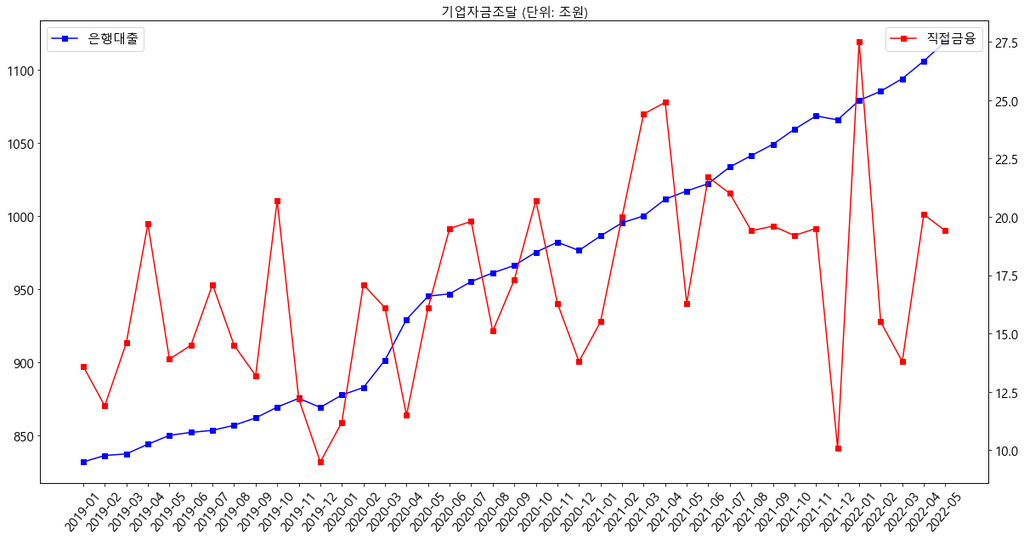

```python
plt.figure(figsize=(20,10))
plt.title('기업자금조달 (단위: 조원)', fontsize=15)


plt.plot(bank_loan.index,bank_loan.values, 'b-',marker='s',label='은행대출')
plt.legend(loc='upper left',fontsize=15)
plt.yticks(fontsize=15)
plt.xticks(rotation=50, fontsize=15)
plt.twinx()

plt.plot(dir_fin.index,dir_fin.values, 'r-',marker='s', label='직접금융')
plt.legend(loc='upper right',fontsize=15)

plt.yticks(fontsize=15)
plt.show()
```

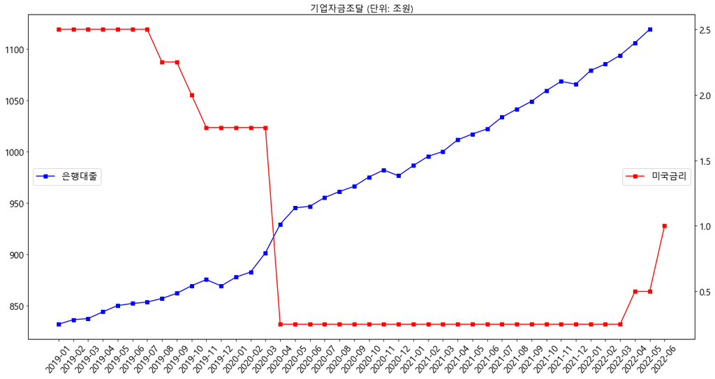

```python
plt.figure(figsize=(20,10))
plt.title('기업자금조달 (단위: 조원)', fontsize=15)


plt.plot(bank_loan.index,bank_loan.values, 'b-',marker='s',label='은행대출')
plt.legend(loc=6,fontsize=15)
plt.yticks(fontsize=15)
plt.xticks(rotation=50, fontsize=15)
plt.twinx()

plt.plot(ame_ir_m['날짜'].values, ame_ir_m['실제'].values, 'r-',marker='s', label='미국금리')
plt.legend(loc=5,fontsize=15)

plt.yticks(fontsize=15)
plt.show()
```

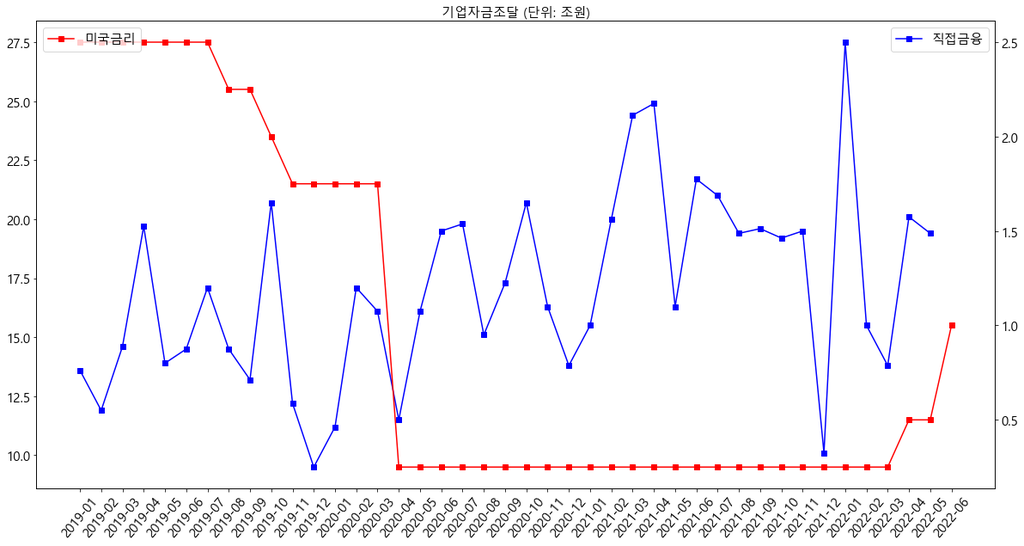

```python
plt.figure(figsize=(20,10))
plt.title('기업자금조달 (단위: 조원)', fontsize=15)


plt.plot(dir_fin.index,dir_fin.values, 'b-',marker='s', label='직접금융')
plt.legend(loc='upper right',fontsize=15)
plt.yticks(fontsize=15)
plt.xticks(rotation=50, fontsize=15)
plt.twinx()

plt.plot(ame_ir_m['날짜'].values, ame_ir_m['실제'].values, 'r-',marker='s', label='미국금리')
plt.legend(loc='upper left',fontsize=15)

plt.yticks(fontsize=15)
plt.show()
```

## '직접금융' 차트 분석

- 직접금융= 주식발행 + 채권발행
- 등락폭은 크지만 금리가 낮아지며 직접금융 그래프는 전체적으로 위로 올라간 모습
- 2년 가까이 초저금리가 지속되며 금리인상 요인과 함께 2021년 말에는 직접금융 등락폭이 커 직접금융조달은 불안정한 모습

## 결론

- 코로나 기간동안 시중에 자금이 풀리며 인플레이션이 발생했고
- 물가를 낮추기 위해 금리가 인상은 필요하나 전쟁 등으로 인한 원유 식량 등의 원자재 수급 불안정으로
- 공급이 부족한 상황.
- 이는 물가는 오르나 경기는 침체되는 스태그플레이션이 발생할 수 있고
- 저금리 기간동안 급격히 증가한 가계와 기업의 부채를 고려해 미국금리 인상을 빠르게 따라가는 것에 주의가 필요해 보임
- 가계와 기업은 금리상승에 대비가 필요